# Proyecto

Osmar Dominique Santana Reyes

2025-10-02

En una base de datos que contiene el Producto Interno Bruto (PIB) de varios países desde el año 1986 al 2023, se realizará lo siguiente:

1. **Cambiar los datos faltantes para una variable por la media y la otra variable por la mediana. Además, los datos atípicos se cambiarán por los máximo y mínimo de los alambres (bigotes).**

   Hay 12 países que tienen datos faltantes, la media y mediana del año 2018 son 17601.66 y 6946.335, respectivamente, además de que el histograma de los datos con la media y mediana trazados es el siguiente:

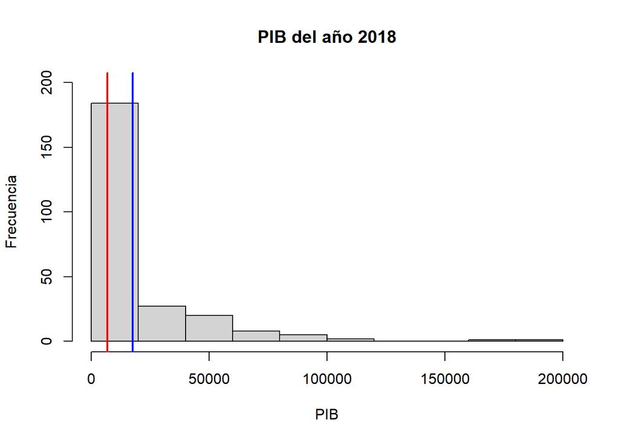

   De esta manera, al ser los datos asimétricos, se usará la mediana como reemplazo de los datos faltantes del 2018, mientras que los del año 2019 se reemplazarán con la media.

   Ahora, los boxplot’s para el año 2018 y 2019 son los siguientes:

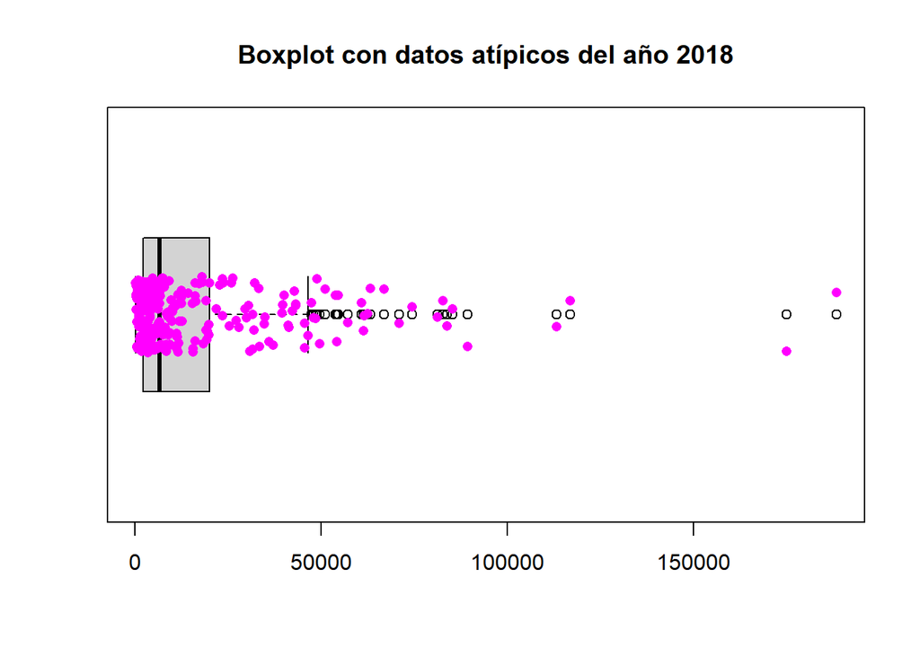

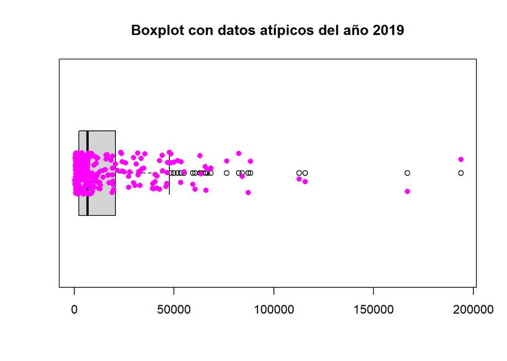

   Se llevarán los datos atípicos a los extremos de los alambres del boxplot en ambas variables (2018 y 2019).

   Así, los boxplot quedan como sigue:

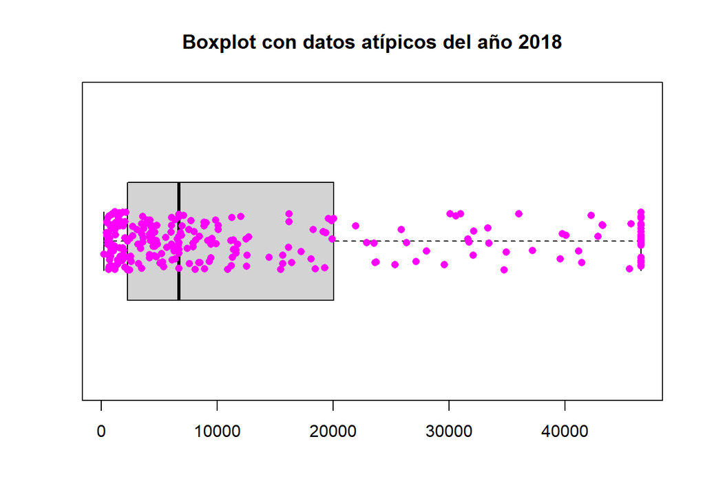

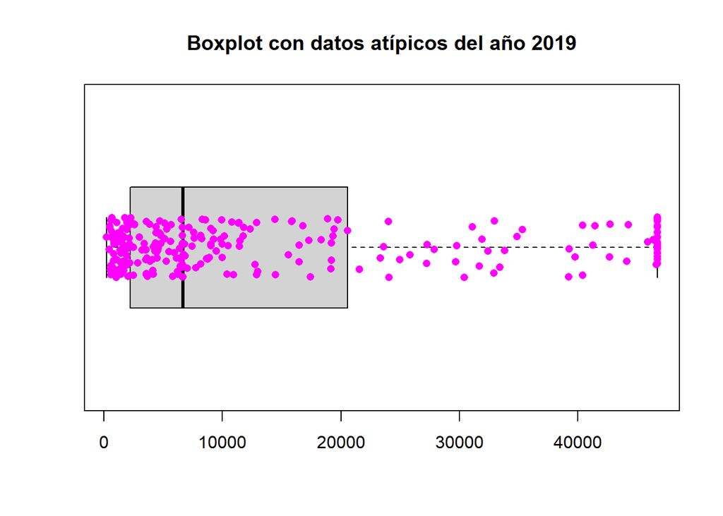

2. **Un análisis descriptivo de las dos variables.**

   Para el año 2018:

   ```
   ## La media del PIB es:  14215.97
   ```

   ```
   ## La mediana del PIB es:  6701.927
   ```

   ```
   ## La moda del PIB es:  46539.18
   ```

   ```
   ## La varianza del PIB es:  245344840
   ```

   ```
   ## La desviación estándar del PIB es:  15663.49
   ```

   ```
   ## El coeficiente de variación es: 110.1824
   ```

   ```
   ## Los cuartiles son: 2273.442 6701.927 20017.38
   ```

   Para el año 2019:

   ```
   ## La media del PIB es:  14240.05
   ```

   ```
   ## La mediana del PIB es:  6643.443
   ```

   ```
   ## La moda del PIB es:  46716.62
   ```

   ```
   ## La varianza del PIB es:  246093767
   ```

   ```
   ## La desviación estándar del PIB es:  15687.38
   ```

   ```
   ## El coeficiente de variación es: 110.1638
   ```

   ```
   ## Los cuartiles son: 2224.218 6643.443 20369.74
   ```

3. **Colocar al menos dos gráficos por cada variable. Dar una pequeña interpretación.**

   Para el año 2018:

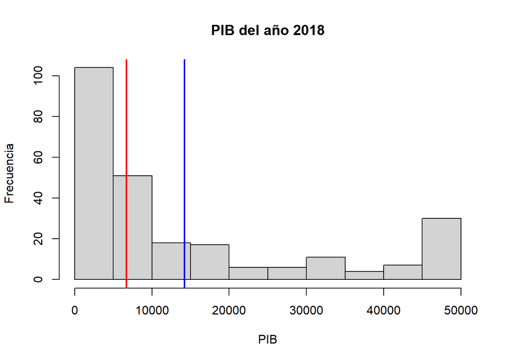

   Para el año 2019:

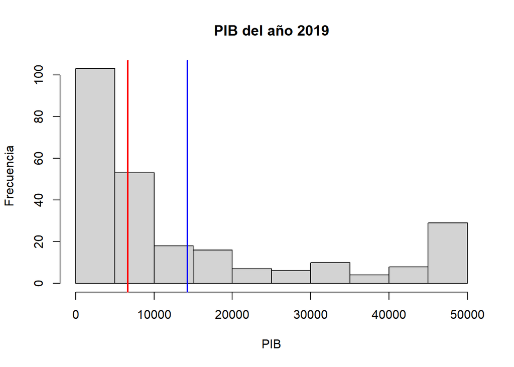

   Dada la semejanza entre ambas gráficas, se graficarán las diferencias entre los PIB de ambos años:

[figure not shown]

   Se puede observar que son muy pocos los casos en los que el PIB varió de un año a otro, además de que tanto la media como la mediana están cerca del 0, por lo que se puede decir que la variación del PIB entre ambos años es muy pequeña. A pesar de esto, es interesante notar que la mayoría de los países pudo incrementar en cierta cantidad su PIB, aunque la mayoría no tuvo un gran incremento, mientras que son muy pocos los que lograron incrementarlo en una gran cantidad.
4. **Realizar una regresión lineal simple de los dos años. Predecir el PIB del año posterior a partir del año anterior. Encontrar el modelo, y decir si es bueno para realizar predicciones (mostrar dos predicciones para dos valores de PIB).**

   ```
   ## La correlación entre ambos años es 0.999521 , que es muy cercano a 1, así se puede decir que ambas variables tienen una muy buena relación lineal.
   ```

   ```
   ##
   ## Call:
   ## lm(formula = X2019 ~ X2018, data = pib)
   ##
   ## Residuals:
   ##      Min       1Q   Median       3Q      Max
   ## -1818.33   -85.18    26.26   122.61  3110.79
   ##
   ## Coefficients:
   ##              Estimate Std. Error t value Pr(>|t|)
   ## (Intercept)  9.223977  41.257178   0.224    0.823
   ## X2018        1.001045   0.001953 512.686   <2e-16 ***
   ## ---
   ## Signif. codes:  0 '***' 0.001 '**' 0.01 '*' 0.05 '.' 0.1 ' ' 1
   ##
   ## Residual standard error: 486.5 on 252 degrees of freedom
   ## Multiple R-squared:  0.999,  Adjusted R-squared:  0.999
   ## F-statistic: 2.628e+05 on 1 and 252 DF,  p-value: < 2.2e-16
   ```

   ```
   ## Analysis of Variance Table
   ##
   ## Response: X2019
   ##            Df     Sum Sq    Mean Sq F value    Pr(>F)
   ## X2018       1 6.2202e+10 6.2202e+10  262847 < 2.2e-16 ***
   ## Residuals 252 5.9635e+07 2.3665e+05
   ## ---
   ## Signif. codes:  0 '***' 0.001 '**' 0.01 '*' 0.05 '.' 0.1 ' ' 1
   ```

   Luego, el coeficiente de determinación del modelo es 0.999, por lo que el ajuste lineal es muy bueno. Además, del ANOVA del modelo se obtiene un p-value de $2.2*10^{-16}$, por lo que el modelo es significativo.

   ```
   ## Non-constant Variance Score Test
   ## Variance formula: ~ fitted.values
   ## Chisquare = 88.20167, Df = 1, p = < 2.22e-16
   ```

   Posteriormente, de la prueba de homocedasticidad, se obtiene un p-value de $2.22 \cdot 10^{-16}$ por lo que se rechaza la hipótesis nula de que la varianza es constante.

   ```
   ##
   ##  Shapiro-Wilk normality test
   ##
   ## data:  residuals(modelo)
   ## W = 0.80092, p-value < 2.2e-16
   ```

   Por otro lado, de la prueba de normalidad se obtiene un p-value de $2.2 \cdot 10^{-16}$ por lo que se rechaza la hipótesis nula de que los errores están distribuidos de manera normal.

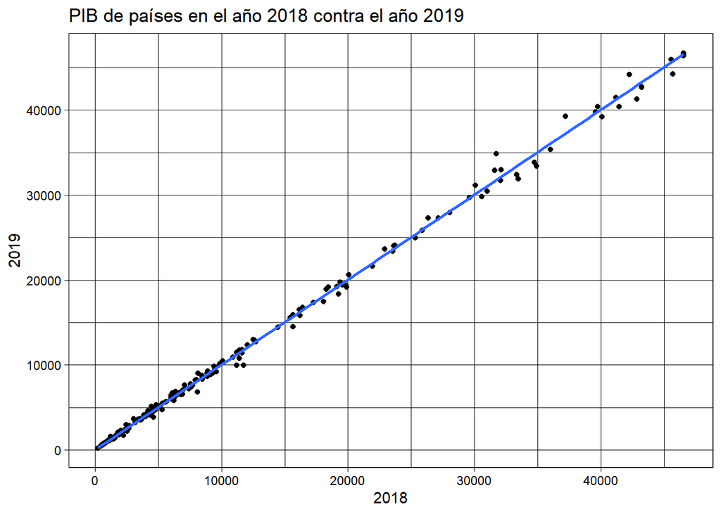

   Aunque los supuestos de homocedasticidad y normalidad no se cumplen, el modelo parece ser lo suficientemente bueno para predecir el PIB del año 2019 a partir del de 2018.

   Por último, utilizando el modelo para predecir el valor del PIB en el año 2019 cuando en el 2018 se tuvo de 10000 y 40000:

   ```
   ##        fit       lwr      upr
   ## 1 10019.68  9957.416 10081.94
   ## 2 40051.04 39935.089 40166.99
   ```

   ```
   ##        fit       lwr      upr
   ## 1 10019.68  9059.603 10979.75
   ## 2 40051.04 39085.994 41016.08
   ```